# ETFs in laboratory asset markets

J. Duffy (UC Irvine), J.P. Rabanal (Monash U), O. Rud (U Melbourne),

## Motivation

- Exchange-Traded Funds (ETF) under management are $4.3 trillion in September 2017 exceeding the hedge fund industry (Lettau and Madhavan, 2018)
- An ETF is an investment vehicle that typically seeks to track the performance of a specific index, like an index mutual fund does.

## Motivation

How do ETFs affect

- price discovery
- trading volume
- free riding
- diversification

## Motivation

Type of ETF:

- does it cover the market?
- correlation between assets
- FV process

## Experimental Design

- 2 x 2 design
- ETF vs. no ETF
- $\rho\in (-1,0)$

## Experimental Design

- A, B and C, where $C= A + B$
- T = 15 periods
- dividend streams:
  - A pays 1 or -1
  - B pays the opposite of A in all periods. Starting from t=8, pays plus 1.
- $FV_{{A,t}}= 10$
- $FV_{B,t}=\left\{\begin{array}{ll} 18 & \mbox{for}\ t \leq 8 \\ (T-t+1) + 10 & \mbox{for}\ t > 8 \end{array} \right.$
- $FV_{C,t}=\left\{\begin{array}{ll} 28 & \mbox{for}\ t \leq 8 \\ (T-t+1) + 20 & \mbox{for}\ t > 8 \end{array} \right.$

## Experimental Design

- Each session: 9 players, 2 big markets
- One market is randomly paid (avoid wealth effects)
- One call market per asset
- Endowments of (A, B, C, cash) according to player type

Endowments

|  | A | B | C | cash |
| --- | --- | --- | --- | --- |
| type I | 8 | 2 | 0 | 444 |
| type II | 2 | 8 | 0 | 396 |
| type III | 0 | 0 | 10 | 280 |

## Experimental Design

- UI in oTree (developed by the authors)

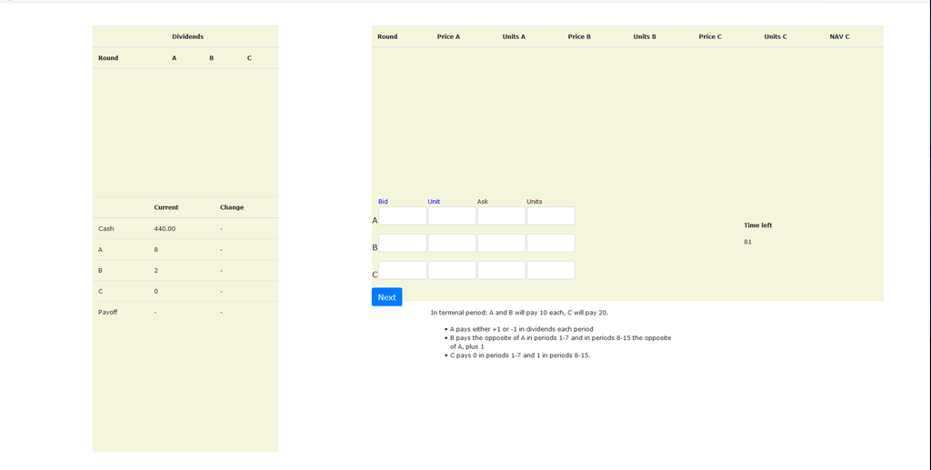

- Subjects: students from UC Irvine

## Results

- Relative absolute deviation from fundamentals
  $$DF = \frac{1}{T}\sum |\frac{P}{F}-1 |$$

DF

| A | B | C |
| --- | --- | --- |
| 1.64 | 0.83 | 1.30 |
| 1.10 | 0.78 | 1.01 |

## Results

- Relative difference from parity pricing
  $$\Delta_{t} = \frac{P_j}{P_i + F_j-F_i}-1$$
- Cross-asset price discrepancy,
  $$PD = \frac{1}{T}\sum \Delta_{t}$$

PD

| B/A | C/A | C/B |
| --- | --- | --- |
| 0.15 | 0.21 | 0.55 |
| 0.11 | 0.24 | 0.38 |

## Market prices

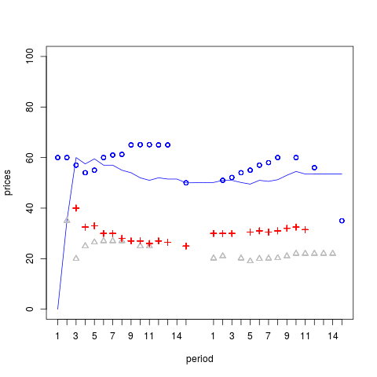

## Market quantities

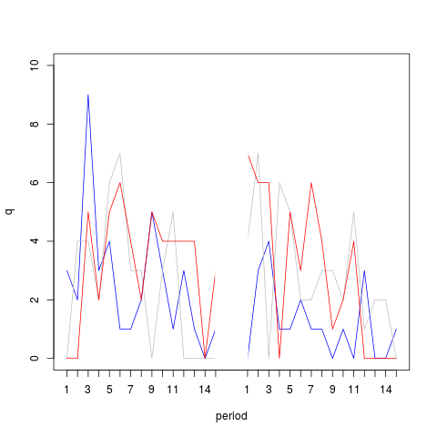

## Portfolio balance A-B

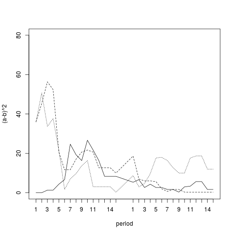

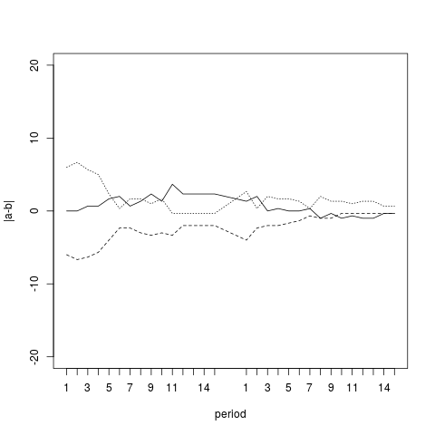

## holdings A,B,C

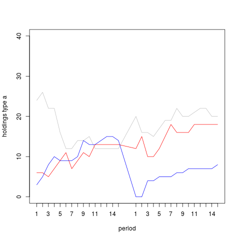

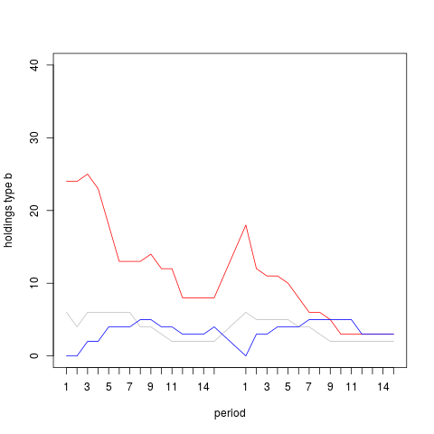

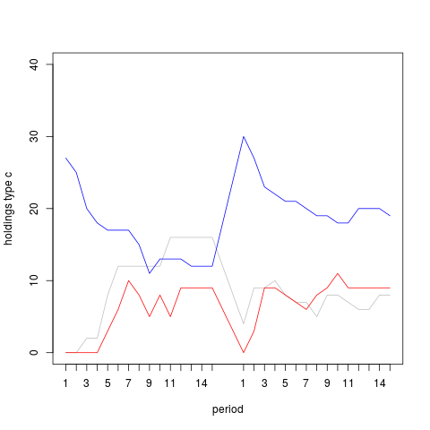

## Two Assets

Measures

| DF A | DF B | PD B/A |
| --- | --- | --- |
| 0.21 | 0.26 | 0.27 |
| 0.79 | 0.34 | 0.21 |

## Market prices

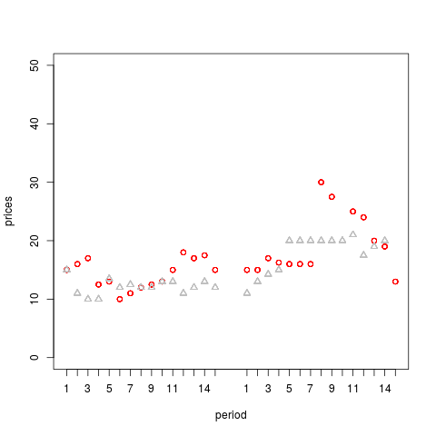

## Market quantities

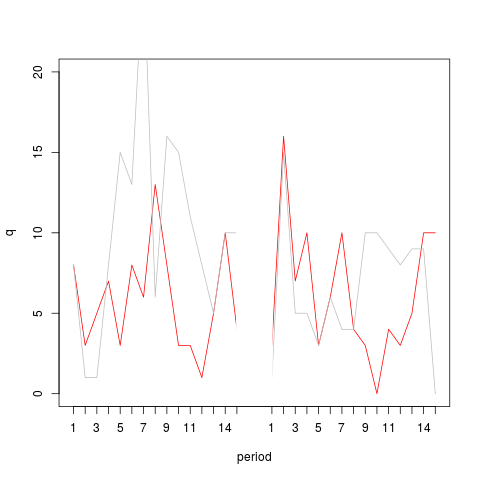

## Portfolio balance A-B

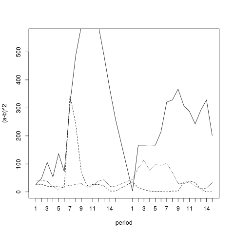

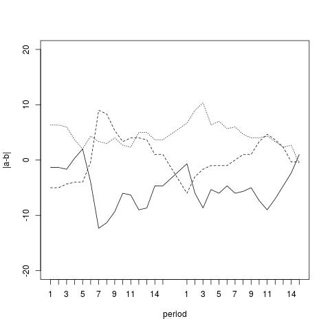

## holdings A,B

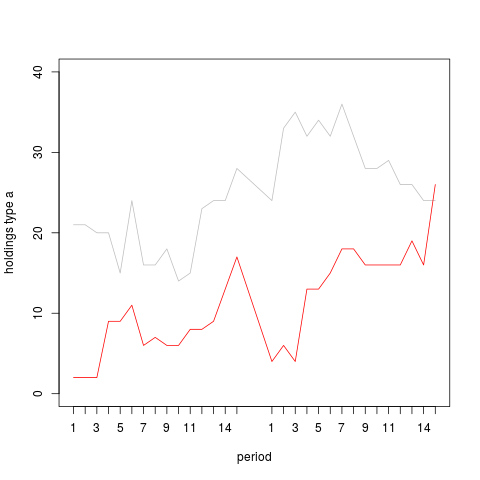

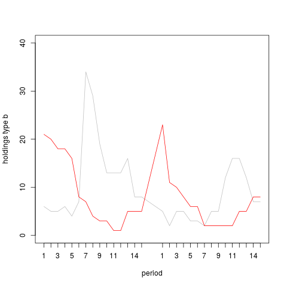

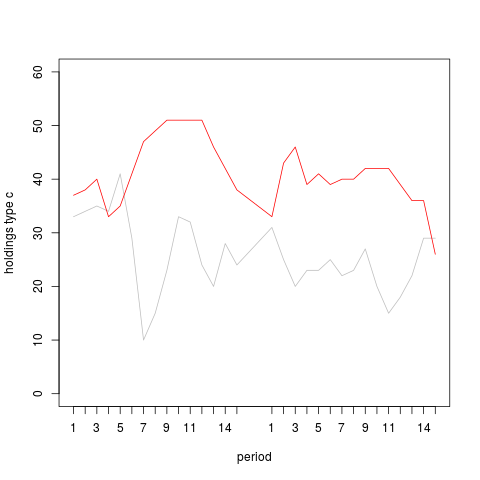

## Ongoing work

- ETFs in a CAPM framework (Bossaerts, Duffy, Fattinger, Rabanal and Rud)